# Tratamiento, Limpieza y Selección de variables

Manuel Rocamora Valenti

2025-04-02

# 1. TRATAMIENTO

En este primer paso, cargaremos los datos y aplicaremos un tratamiento previo, incluyendo la combinación de variables duplicadas y la renombración de columnas para mejorar su comprensión.

## 1.2 Carga de librerías

```r
library(readxl)
library(dplyr)
```

```r
library(ggplot2)
library(mice)
library(reshape2)
```

## 1.3 Carga de datos

```r
# Reemplaza "datos.xlsx" y "hoja1" con el nombre real de tu archivo y hoja
datos <- read_excel("/Users/manuelrocamoravalenti/Desktop/TFG/Datos_Crudo/DatosAnalisisPrediccion.xlsx")
```

## 1.4 Cambios de algunos nombres

En este punto, cambiamos los nombre de algunas Variables al ingles.

```r
names(datos)[names(datos) == "Joven(0)_Anciano(1)"] <- "Elderly"
names(datos)[names(datos) == "%_perd_peso"] <- "Percentage_weight_loss"
names(datos)[names(datos) == "PD-L1"] <- "PD_L1"
names(datos)[names(datos) == "1ª_eval"] <- "First_evaluation"
names(datos)[names(datos) == "1ªeval_num"] <- "First_evaluation_num"
names(datos)[names(datos) == "Progresión_sí/no"] <- "Progression"
names(datos)[names(datos) == "2ªL_sí/no"] <- "second_line_treatment"
names(datos)[names(datos) == "Exitus_sí/no"] <- "Exitus"
names(datos)[names(datos) == "Sexo"] <- "Sex"
```

## 1.5 Combinacion de variables repetidas

Existen algunas variables repetidas en el conjunto de datos, las cuales, algunas está completas en un paciente y otras no, la finalidad de combinarlas es rear una sola columna mas completa.

```r
datos <- datos %>%
  mutate(estudios = coalesce(`Estudios...14`, `Estudios...29`)) %>%
  select(-`Estudios...14`, -`Estudios...29`)

datos <- datos %>%
  mutate(est_civil = coalesce(`Est_civil...15`, `Est_civil...31`)) %>%
  select(-`Est_civil...15`, -`Est_civil...31`)

datos <- datos %>%
  mutate(hogar = coalesce(`Comp_hogar...16`, `Comp_hogar...32`)) %>%
  select(-`Comp_hogar...16`, -`Comp_hogar...32`)

datos <- datos %>%
  mutate(MOOSs = coalesce(`MOSs...17`, `MOSs...33`)) %>%
  select(-`MOSs...17`, -`MOSs...33`)

datos <- datos %>%
  mutate(ansiedad = coalesce(`Ansiedad...18`, `Ansiedad...36`)) %>%
  select(-`Ansiedad...18`, -`Ansiedad...36`)

datos <- datos %>%
  mutate(depresion = coalesce(`Depresion...19`, `Depresion...37`)) %>%
  select(-`Depresion...19`, -`Depresion...37`)

datos <- datos %>%
  mutate(MNA = coalesce(`MNA...20`, `MNA...27`)) %>%
  select(-`MNA...20`, -`MNA...27`)
```

Las variables de ‘estudio’ y ‘hogar’, como tienen tan pocos valores faltante, vamos a sustituir los espacios vacios, por el valor ‘Unknown’.

```r
datos$estudios[is.na(datos$estudios)] <- "Unknown"
datos$hogar[is.na(datos$hogar)] <- "Unknown"
```

# 2. LIMPIEZA

Para garantizar la calidad del análisis, es necesario limpiar el conjunto de datos eliminando aquellas columnas con un alto porcentaje de valores faltantes.

Esto nos permite reducir el impacto de datos incompletos y mejorar la fiabilidad de los resultados obtenidos.

## 2.1 Eliminación de columnas previa

Las columnas que vamos a eliminar no le dan valor alguno al análisis, es por ello que se eliminan manualmente, algunas de ellas como las fechas y las variables respuesta. (First_evaluation, Second_evaluation), serán vitales en futuros análisis.

```r
datos <- datos %>% select(-Num_pac, -Fecha_nac, -Fecha_dx, -Peso, -Talla,
                          -G8, -Audicion, -Barthel, -Lawton_Brody, -SPPB,
                          -Caida_6m, -Pfeiffer, -Mini_mental, -Social_Gijon,
                          -Yesavage, -CIRS, -Charlson, -Polifarmacia, -Sd_geriatr,
                          -Clasif_geriatr_Balducci, -Clasif_geriatr_SIOG1,
                          -Biopsia_liq, -Tipo_mut_Liq, -Fecha_inicio_pem, -Mejor_resp,
                          -Fecha_exitus, -Fecha_últ_control, -Fecha_SLP, -Fecha_SG,
                          -Fecha_progresión, -Observaciones, -'Leuc%', -'Linf%',
                          -'CD45+', -First_evaluation, -First_evaluation_num,
                          -Mejor_resp_num, -T, -N, -M, -'Toxicidad_si/no',
                          -Tipo_tox, -Grado_tox, -SG, -SG_cens)
```

## 2.2 Análisis de datos faltantes (Columnas)

Ahora vamos a calcular el porcentaje de valores faltantes por columna, crear un resumen con los resultados y ordenarlos de mayor a menor segun su porcentaje.

```r
# Calcular el porcentaje de valores faltantes por columna
missing_percent <- colSums(is.na(datos)) / nrow(datos) * 100

# Crear un dataframe con el resumen de valores faltantes
missing_summary <- data.frame(Columna = names(missing_percent), Porcentaje_Faltante = missing_percent)

# Mostrar el resumen
dplyr::arrange(missing_summary, desc(Porcentaje_Faltante))
```

```
##                                         Columna Porcentaje_Faltante
## CD3_C_Leuc                           CD3_C_Leuc          100.000000
## CD4+_C_CD45                         CD4+_C_CD45          100.000000
## CD45+_C                                 CD45+_C          100.000000
## CD127-/lowFoxP3+_%CD4     CD127-/lowFoxP3+_%CD4           91.176471
## CD25+FoxP3+_%Linf             CD25+FoxP3+_%Linf           91.176471
## CD39+FoxP3+_%CD4               CD39+FoxP3+_%CD4           91.176471
## CD4+_%CD45                           CD4+_%CD45           91.176471
## CD45RA+_%Linf                     CD45RA+_%Linf           91.176471
## CD45RA+FoxP3+_%CD4           CD45RA+FoxP3+_%CD4           91.176471
## Helios+FoxP3+_%CD4           Helios+FoxP3+_%CD4           91.176471
## CD127-/lowFoxP3+_C_CD4   CD127-/lowFoxP3+_C_CD4           91.176471
## CD25+FoxP3+_C_Linf           CD25+FoxP3+_C_Linf           91.176471
## CD39+FoxP3+_C_CD4             CD39+FoxP3+_C_CD4           91.176471
## CD45RA+_C_Linf                   CD45RA+_C_Linf           91.176471
## CD45RA+FoxP3+_C_CD4         CD45RA+FoxP3+_C_CD4           91.176471
## Helios+FoxP3+_C_CD4         Helios+FoxP3+_C_CD4           91.176471
## CD25+CD127low_%Linf         CD25+CD127low_%Linf           73.529412
## CD25+CD127low_C_Linf       CD25+CD127low_C_Linf           73.529412
## HLADR+Lin_%Leuc                 HLADR+Lin_%Leuc           64.705882
## mDC_%Leuc                             mDC_%Leuc           64.705882
## pDC_%Leuc                             pDC_%Leuc           64.705882
## CD4_Central_Mem_%Linf     CD4_Central_Mem_%Linf           64.705882
## CD4_Effector_Mem_%Linf   CD4_Effector_Mem_%Linf           64.705882
## CD4_Naïve_%Linf                 CD4_Naïve_%Linf           64.705882
## CD4_TEMRA_%Linf                 CD4_TEMRA_%Linf           64.705882
## CD8_Central_Mem_%Linf     CD8_Central_Mem_%Linf           64.705882
## CD8_Effector_Mem_%Linf   CD8_Effector_Mem_%Linf           64.705882
## CD8_Naïve_%Linf                 CD8_Naïve_%Linf           64.705882
## CD8_TEMRA_%Linf                 CD8_TEMRA_%Linf           64.705882
## mDC_CD16_%mDC                     mDC_CD16_%mDC           64.705882
## mDC_CD1c_%mDC                     mDC_CD1c_%mDC           64.705882
## mDC_Clec9A_%mDC                 mDC_Clec9A_%mDC           64.705882
## CD3+_%Linf                           CD3+_%Linf           64.705882
## CD27-CD57+CD3+_%Linf       CD27-CD57+CD3+_%Linf           64.705882
## CD27-CD57+CD4+_%CD3         CD27-CD57+CD4+_%CD3           64.705882
## CD27-CD57+CD8+_%CD3         CD27-CD57+CD8+_%CD3           64.705882
## CD3_%Leuc                             CD3_%Leuc           64.705882
## CD3+CD4+_%Linf                   CD3+CD4+_%Linf           64.705882
## CD3+CD57+_%Linf                 CD3+CD57+_%Linf           64.705882
```

[output cut: 161 more lines]

```
## Linf_1eval                           Linf_1eval            0.000000
## Plaq_1eval                           Plaq_1eval            0.000000
## NLR_1eval                             NLR_1eval            0.000000
## PLR_1eval                             PLR_1eval            0.000000
## PNI_1eval                             PNI_1eval            0.000000
## SII_1eval                             SII_1eval            0.000000
## N_ciclos                               N_ciclos            0.000000
## Interrupc_tto                     Interrupc_tto            0.000000
## Motivo_inter                       Motivo_inter            0.000000
## Progression                         Progression            0.000000
## Exitus                                   Exitus            0.000000
## SLP                                         SLP            0.000000
## SLP_cens                               SLP_cens            0.000000
## estudios                               estudios            0.000000
## hogar                                     hogar            0.000000
```

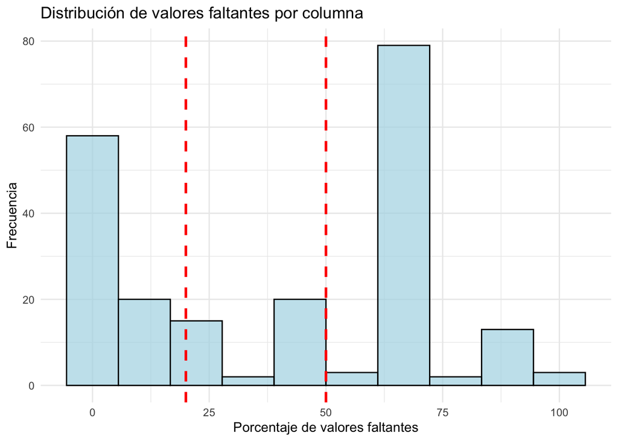

```r
# Crear un dataframe con los porcentajes de valores faltantes por columna
df_missing_col <- data.frame(Porcentaje_Faltante = missing_percent)

# Generar el histograma
ggplot(df_missing_col, aes(x = Porcentaje_Faltante)) +
  geom_histogram(bins = 10, fill = "lightblue", color = "black", alpha = 0.7) +
  geom_vline(xintercept = 20, color = "red", linetype = "dashed", size = 1, label = "Umbral 20%") +
  geom_vline(xintercept = 50, color = "red", linetype = "dashed", size = 1, label = "Umbral 50%") +
  labs(title = "Distribución de valores faltantes por columna",
       x = "Porcentaje de valores faltantes",
       y = "Frecuencia") +
  theme_minimal()
```

```r
threshold <- 24  # Umbral de eliminación
datos_limpios <- datos %>% select(which(missing_percent <= threshold))

# Verificar las columnas eliminadas
columnas_eliminadas <- names(missing_percent[missing_percent > threshold])
```

Por lo que las columnas que quedan **dentro del analisis** son las siguientes:

```r
colnames(datos_limpios)
```

```
##  [1] "Idpac"                  "Sex"                    "Edad_dx"
##  [4] "Elderly"                "ECOG"                   "IMC"
##  [7] "Percentage_weight_loss" "p_peso_no_sí"           "Hab_tabaq"
## [10] "Exp_tab"                "Diabetes"               "Cardiop"
## [13] "Enf_neurod"             "Histologia"             "Histología_num"
## [16] "Estadio"                "Estadio_num"            "PD_L1"
## [19] "Estado_mut"             "Estatinas"              "Col_total"
## [22] "LDH"                    "Prot_tot"               "Albumina"
## [25] "PCR"                    "Hb"                     "Leucoc_tot"
## [28] "Neutrofilos"            "Linf_tot"               "Plaquetas"
## [31] "NLR_pre"                "PLR_pre"                "PNI_pre"
## [34] "ALI_pre"                "SII_pre"                "Prot_1C"
## [37] "Alb_1C"                 "Hb_1C"                  "Leucoc_1C"
## [40] "Neutr_1C"               "Linf_1C"                "Plaq_1C"
## [43] "NLR_1C"                 "NLR1C_corte4"           "NLR1C_corte5"
## [46] "PLR_1C"                 "PNI_1C"                 "SII_1C"
## [49] "Prot_2C"                "Alb_2C"                 "Hb_2C"
## [52] "Leucoc_2C"              "Neutr_2C"               "Linf_2C"
## [55] "Plaq_2C"                "NLR_2C"                 "NLR2C_corte4o5"
## [58] "PLR_2C"                 "PNI_2C"                 "SII_2C"
## [61] "Prot_1eval"             "Alb_1eval"              "Hb_1eval"
## [64] "Leucoc_1eval"           "Neutr_1eval"            "Linf_1eval"
## [67] "Plaq_1eval"             "NLR_1eval"              "PLR_1eval"
## [70] "PNI_1eval"              "SII_1eval"              "N_ciclos"
## [73] "Interrupc_tto"          "Motivo_inter"           "Progression"
## [76] "second_line_treatment"  "Exitus"                 "SLP"
## [79] "SLP_cens"               "estudios"               "hogar"
```

```r
writeLines(colnames(datos_limpios), "nombres_columnas_n.txt")
```

### Contexto PCR

En el contexto de **cáncer de pulmón tratado con inmunoterapia**, la **PCR** hace referencia a la **Proteína C Reactiva**, un marcador de inflamación medido en sangre. Esta proteína es producida por el hígado en respuesta a procesos inflamatorios, infecciones o progresión tumoral, y su medición puede aportar información útil sobre el estado clínico del paciente. En pacientes que reciben inmunoterapia (como nivolumab o pembrolizumab), una **PCR elevada antes o durante el tratamiento** se ha asociado en algunos estudios con **peor pronóstico**, **menor respuesta a la terapia** y **mayor riesgo de progresión del cáncer**. Por ello, la PCR puede utilizarse como herramienta para **monitorizar la inflamación sistémica**, detectar posibles **eventos adversos inmunomediados** o diferenciar entre progresión tumoral e infección. Aunque su papel como **biomarcador pronóstico** aún se encuentra en investigación, en general se ha observado que **niveles bajos de PCR** se correlacionan con **mejor respuesta a la inmunoterapia** y mayor supervivencia, mientras que niveles altos podrían indicar la necesidad de una evaluación clínica más detallada.

Como podemos observar la variable ‘PCR’ es de gran interés para este tipo de tratamiento, por lo tanto es importante revisar que entra en el 23% de Nan’s

OJO !! ¿Es una posible **variable respuesta**????

```r
datos_limpios$PCR
```

```
##  [1]  NA  NA   7   6   8  24  92   0  70  54  52  43  35  53  40  17   9  64  22
## [20]  40  NA  47  68  NA  99  12   0  NA  52  NA 107  NA  12  NA
```

Por último, cambiamos al ingles el resto de variables

```r
colnames(datos_limpios) <- c(
  "Patient_ID", "Sex", "Age_at_diagnosis", "Elderly", "ECOG", "BMI", "Percentage_weight_loss",
  "Weight_loss_yes_no", "Smoking_habit", "Smoking_exposure", "Diabetes", "Cardiopathy", "Neurodegenerative_disease", "Histology",
  "Histology_num", "Stage", "Stage_num", "PD_L1", "Mutation_status", "Statins", "Total_cholesterol",
  "LDH", "Total_protein", "Albumin", "CRP", "Hemoglobin", "Total_leukocytes", "Neutrophils", "Total_lymphocytes",
  "Platelets", "NLR_pre", "PLR_pre", "PNI_pre", "ALI_pre", "SII_pre", "Protein_1C", "Albumin_1C",
  "Hemoglobin_1C", "Leukocytes_1C", "Neutrophils_1C", "Lymphocytes_1C", "Platelets_1C", "NLR_1C", "NLR1C_cut4",
  "NLR1C_cut5", "PLR_1C", "PNI_1C", "SII_1C", "Protein_2C", "Albumin_2C", "Hemoglobin_2C",
  "Leukocytes_2C", "Neutrophils_2C", "Lymphocytes_2C", "Platelets_2C", "NLR_2C", "NLR2C_cut4or5", "PLR_2C",
  "PNI_2C", "SII_2C", "Protein_1eval", "Albumin_1eval", "Hemoglobin_1eval", "Leukocytes_1eval", "Neutrophils_1eval",
  "Lymphocytes_1eval", "Platelets_1eval", "NLR_1eval", "PLR_1eval", "PNI_1eval", "SII_1eval", "Number_of_cycles",
  "Treatment_interruption", "Interruption_reason", "Progression", "Second_line_treatment", "Exitus", "PFS",
  "PFS_censored", "Education", "Household"
)
```

## 2.3 Análisis de datos faltantes (Filas)

Hasta ahora, hemos analizado los datos faltantes por columna, pero ahora es momento de hacerlo por filas, así que procedamos con ello.

```r
# Calcular el porcentaje de valores faltantes por fila
datos_limpios$Porcentaje_NA_Fila <- rowSums(is.na(datos_limpios)) / ncol(datos_limpios) * 100

# Crear el dataframe incluyendo el identificador del paciente
df_missing <- data.frame(Patient_ID = datos_limpios$Patient_ID,
                         Porcentaje_NA_Fila = datos_limpios$Porcentaje_NA_Fila)

df_missing
```

```
##    Patient_ID Porcentaje_NA_Fila
## 1        P_01           4.938272
## 2        P_02           1.234568
## 3        P_03           0.000000
## 4        P_04           3.703704
## 5        P_05           2.469136
## 6        P_06           1.234568
## 7        P_07           1.234568
## 8        P_08          16.049383
## 9        P_09           6.172840
## 10       P_10           0.000000
## 11       P_11           2.469136
## 12       P_12           0.000000
## 13       P_13           0.000000
## 14       P_14           0.000000
```

[output cut: 20 more lines]

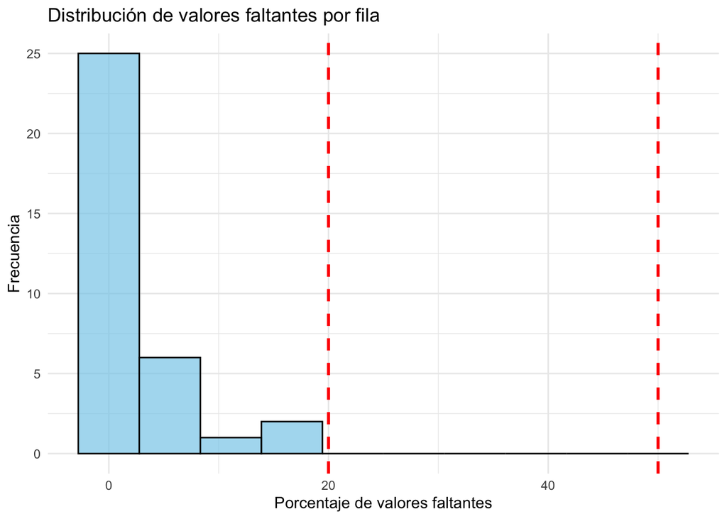

```r
# Crear el histograma
library(ggplot2)
ggplot(df_missing, aes(x = Porcentaje_NA_Fila)) +
  geom_histogram(bins = 10, fill = "skyblue", color = "black", alpha = 0.7) +
  geom_vline(xintercept = 20, color = "red", linetype = "dashed", linewidth = 1) +
  geom_vline(xintercept = 50, color = "red", linetype = "dashed", linewidth = 1) +
  labs(title = "Distribución de valores faltantes por fila",
       x = "Porcentaje de valores faltantes",
       y = "Frecuencia") +
  theme_minimal()
```

```r
# Eliminar los pacientes P_17 y P_21
#datos_limpios <- datos_limpios %>%
 # filter(!(Patient_ID %in% c("P_17", "P_21")))

# Verificar que los pacientes han sido eliminados
#print(unique(datos_limpios$Patient_ID))
```

Eliminamos la columna que hemos creada de procentaje de Na`s

```r
# Eliminar por nombre
datos_limpios <- datos_limpios %>% select(-Porcentaje_NA_Fila)
```

# 3. IMPUTACION

En este apartado abordaremos la imputación de datos faltantes, con la libreria mice.

```r
tipos_var <- data.frame(Columna = names(datos))
tipos_var$Tipo <- sapply(datos, function(x) class(x)[1])
tipos_var
```

```
##                     Columna      Tipo
## 1                     Idpac character
## 2                       Sex   numeric
## 3                   Edad_dx   numeric
## 4                   Elderly   numeric
## 5                      ECOG   numeric
## 6                       IMC   numeric
## 7    Percentage_weight_loss   numeric
## 8              p_peso_no_sí   numeric
## 9                 Hab_tabaq   numeric
## 10                  Exp_tab   numeric
## 11                 Diabetes   numeric
## 12                  Cardiop   numeric
## 13               Enf_neurod   numeric
## 14               Histologia character
```

[output cut: 201 more lines]

```r
write.csv(tipos_var, "tipos_columnas.csv", row.names = FALSE)

datos = datos_limpios
```

Antes de continuar, tenemos que transformar a *factor* aquellas variables que son de naturaleza categorica.

```r
# Convertir las columnas a sus respectivos tipos de datos
datos$Sex <- as.factor(datos$Sex)
datos$ECOG <- as.factor(datos$ECOG)
datos$Smoking_habit <- as.factor(datos$Smoking_habit)
datos$Weight_loss_yes_no <- as.factor(datos$Weight_loss_yes_no)
datos$Diabetes <- as.factor(datos$Diabetes)
datos$Cardiopathy <- as.factor(datos$Cardiopathy)
datos$Neurodegenerative_disease <- as.factor(datos$Neurodegenerative_disease)
datos$Histology <- as.factor(datos$Histology)
datos$Stage <- as.factor(datos$Stage)
datos$Statins <- as.factor(datos$Statins)
datos$NLR1C_cut4 <- as.factor(datos$NLR1C_cut4)
datos$NLR1C_cut5 <- as.factor(datos$NLR1C_cut5)
datos$Histology_num <- as.factor(datos$Histology_num)
datos$Stage_num <- as.factor(datos$Stage_num)
datos$Second_line_treatment <- as.factor(datos$Second_line_treatment)
# Convertir las columnas numéricas correctamente
datos$Age_at_diagnosis <- as.numeric(datos$Age_at_diagnosis)
datos$BMI <- as.numeric(datos$BMI)
datos$Percentage_weight_loss <- as.numeric(datos$Percentage_weight_loss)
datos$Total_cholesterol <- as.numeric(datos$Total_cholesterol)
datos$LDH <- as.numeric(datos$LDH)
datos$Total_protein <- as.numeric(datos$Total_protein)
datos$Albumin <- as.numeric(datos$Albumin)
datos$CRP <- as.numeric(datos$CRP)
datos$Hemoglobin <- as.numeric(datos$Hemoglobin)
datos$Total_leukocytes <- as.numeric(datos$Total_leukocytes)
datos$Neutrophils <- as.numeric(datos$Neutrophils)
datos$Total_lymphocytes <- as.numeric(datos$Total_lymphocytes)
datos$Platelets <- as.numeric(datos$Platelets)
```

Comprobamos que el cambio ha sido correcto

```r
tipos_var <- data.frame(Columna = names(datos))
tipos_var$Tipo <- sapply(datos, function(x) class(x)[1])
tipos_var
```

```
##                      Columna      Tipo
## 1                 Patient_ID character
## 2                        Sex    factor
## 3           Age_at_diagnosis   numeric
## 4                    Elderly   numeric
## 5                       ECOG    factor
## 6                        BMI   numeric
## 7     Percentage_weight_loss   numeric
## 8         Weight_loss_yes_no    factor
## 9              Smoking_habit    factor
## 10          Smoking_exposure   numeric
## 11                  Diabetes    factor
## 12               Cardiopathy    factor
## 13 Neurodegenerative_disease    factor
## 14                 Histology    factor
```

[output cut: 67 more lines]

## 3.1. Metodo Cart

El paso previo a la imputacion de los datos es visualizar con el grafico *md.pattern* de la libreria mice aquellas posibles columnas que contengán un numero muy elevado y se nos puedan haber pasado.

Al tener tantisimas variables, las vamos a graficar de 5 en 5.

```
##
## 🔹 Mostrando patrón de faltantes para variables 1 a 5
##
##  /\     /\
## {  `---'  }
## {  O   O  }
## ==>  V <==  No need for mice. This data set is completely observed.
##  \  \|/  /
##   `-----'
```

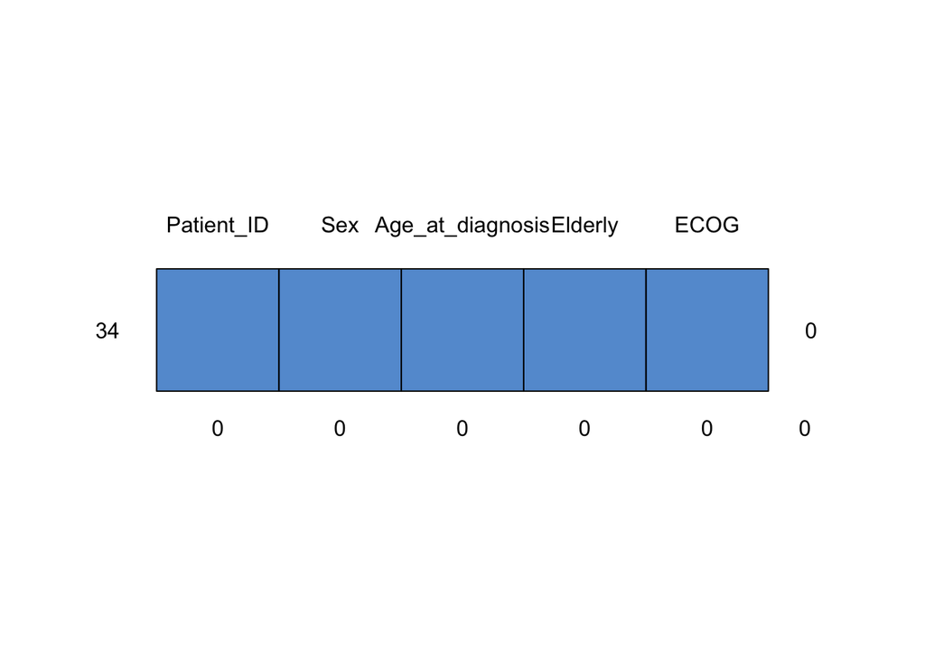

```
##    Patient_ID Sex Age_at_diagnosis Elderly ECOG
## 34          1   1                1       1    1 0
##             0   0                0       0    0 0
##
## 🔹 Mostrando patrón de faltantes para variables 6 a 10
```

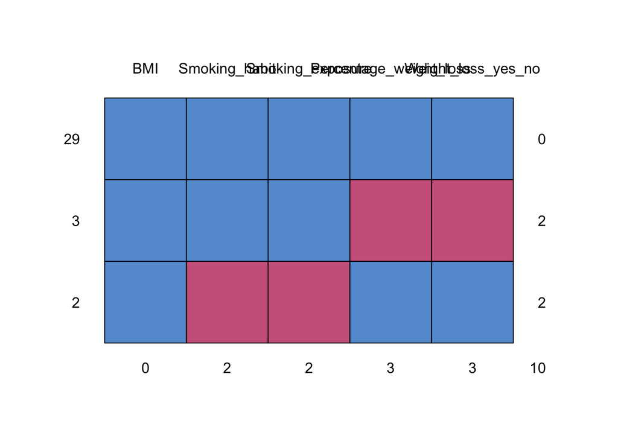

```
##    BMI Smoking_habit Smoking_exposure Percentage_weight_loss Weight_loss_yes_no
## 29   1             1                1                      1                  1
## 3    1             1                1                      0                  0
## 2    1             0                0                      1                  1
##      0             2                2                      3                  3
##
## 29  0
## 3   2
## 2   2
##    10
##
## 🔹 Mostrando patrón de faltantes para variables 11 a 15
##
##  /\     /\
## {  `---'  }
## {  O   O  }
## ==>  V <==  No need for mice. This data set is completely observed.
##  \  \|/  /
##   `-----'
```

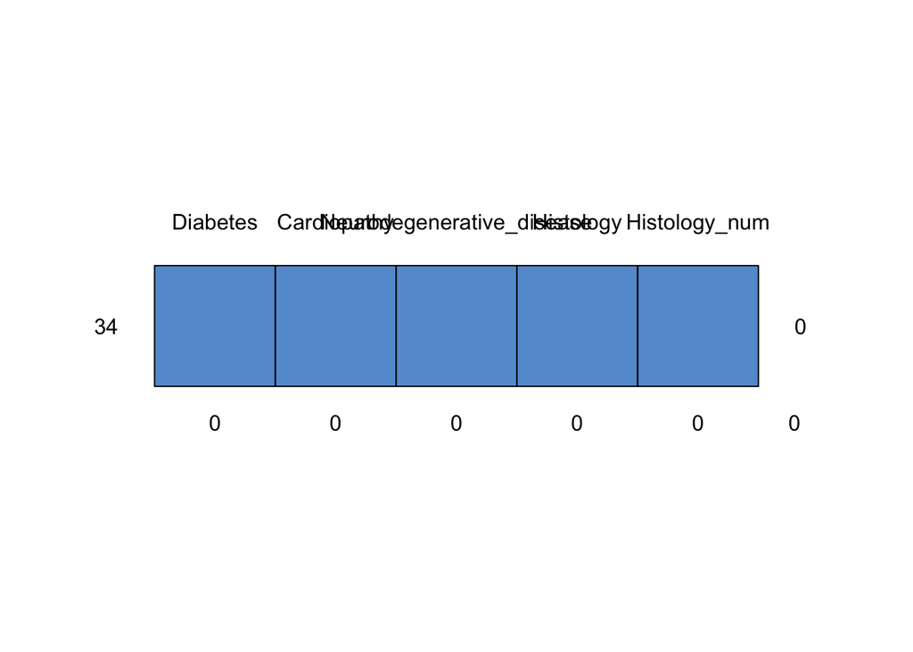

```
##    Diabetes Cardiopathy Neurodegenerative_disease Histology Histology_num
## 34        1           1                         1         1             1 0
##           0           0                         0         0             0 0
##
## 🔹 Mostrando patrón de faltantes para variables 16 a 20
```

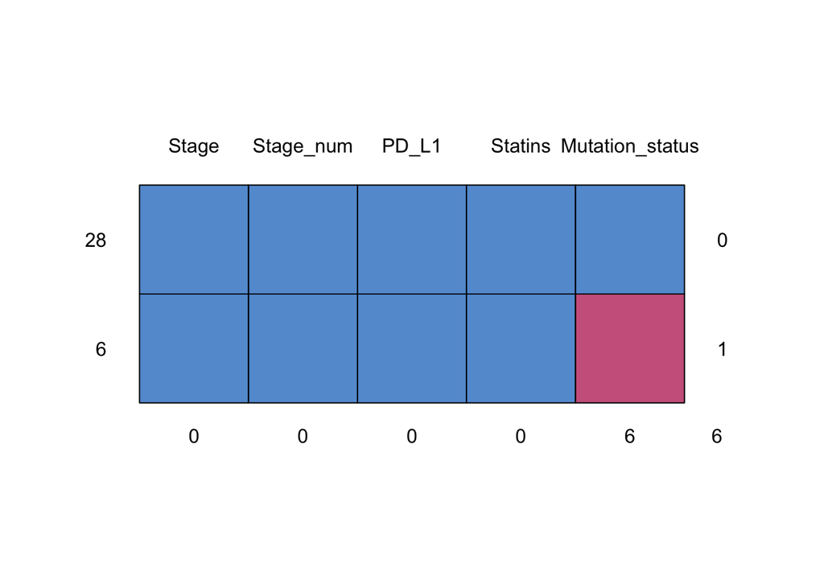

```
##    Stage Stage_num PD_L1 Statins Mutation_status
## 28     1         1     1       1               1 0
## 6      1         1     1       1               0 1
##        0         0     0       0               6 6
##
## 🔹 Mostrando patrón de faltantes para variables 21 a 25
```

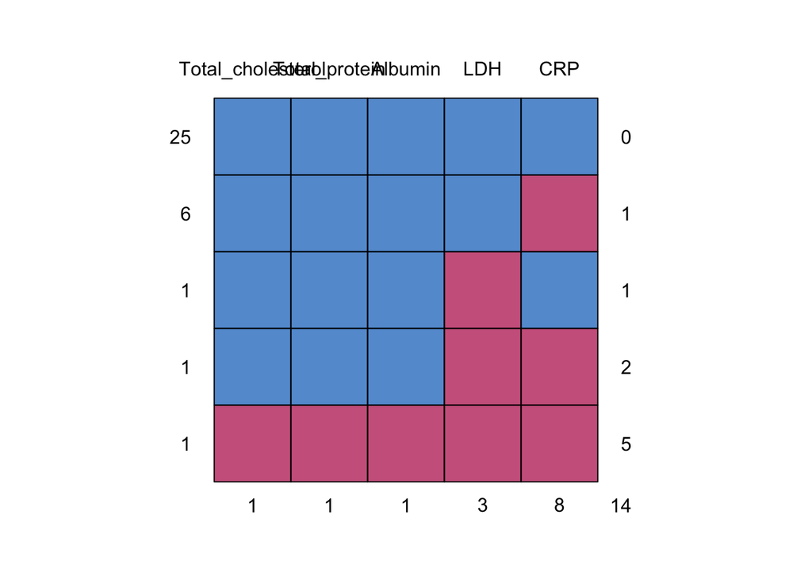

```
##    Total_cholesterol Total_protein Albumin LDH CRP
## 25                 1             1       1   1   1  0
## 6                  1             1       1   1   0  1
## 1                  1             1       1   0   1  1
## 1                  1             1       1   0   0  2
## 1                  0             0       0   0   0  5
##                    1             1       1   3   8 14
##
## 🔹 Mostrando patrón de faltantes para variables 26 a 30
##
##  /\     /\
## {  `---'  }
## {  O   O  }
## ==>  V <==  No need for mice. This data set is completely observed.
##  \  \|/  /
##   `-----'
```

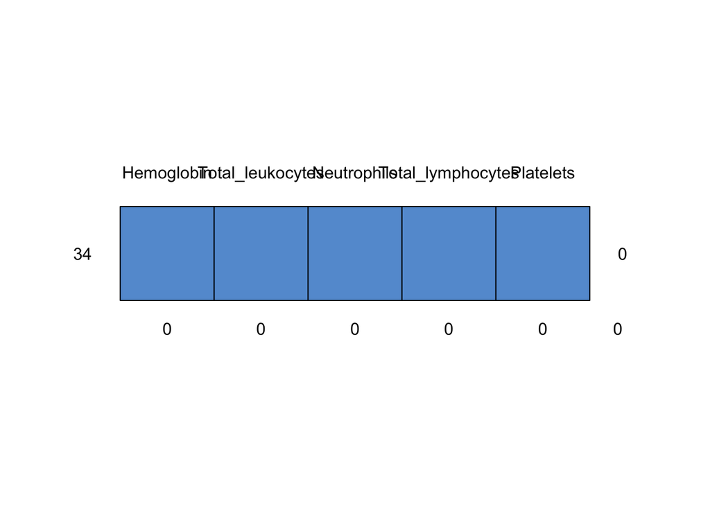

```
##    Hemoglobin Total_leukocytes Neutrophils Total_lymphocytes Platelets
## 34          1                1           1                 1         1 0
##             0                0           0                 0         0 0
##
## 🔹 Mostrando patrón de faltantes para variables 31 a 35
```

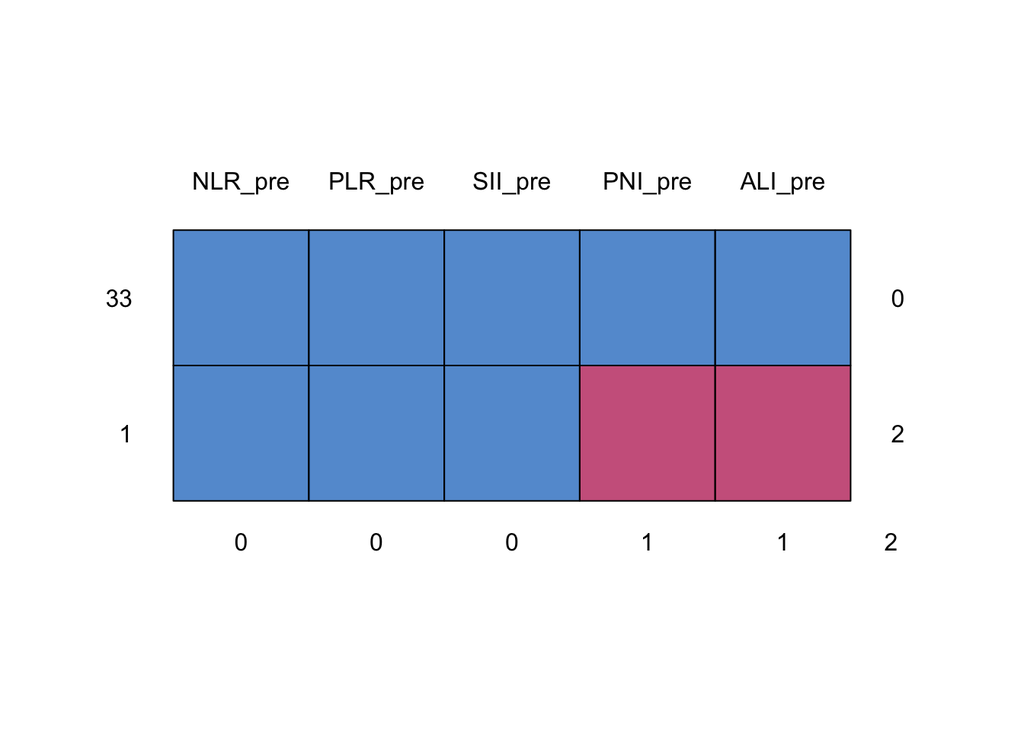

```
##    NLR_pre PLR_pre SII_pre PNI_pre ALI_pre
## 33       1       1       1       1       1 0
## 1        1       1       1       0       0 2
##          0       0       0       1       1 2
##
## 🔹 Mostrando patrón de faltantes para variables 36 a 40
```

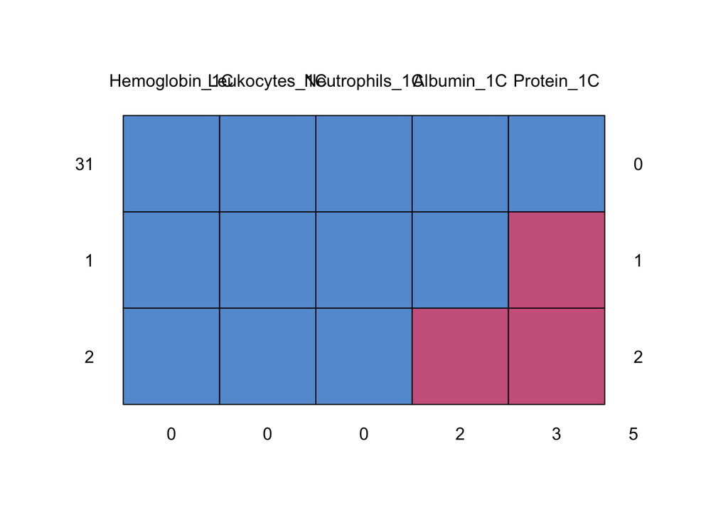

```
##    Hemoglobin_1C Leukocytes_1C Neutrophils_1C Albumin_1C Protein_1C
## 31             1             1              1          1          1 0
## 1              1             1              1          1          0 1
## 2              1             1              1          0          0 2
##                0             0              0          2          3 5
##
## 🔹 Mostrando patrón de faltantes para variables 41 a 45
```

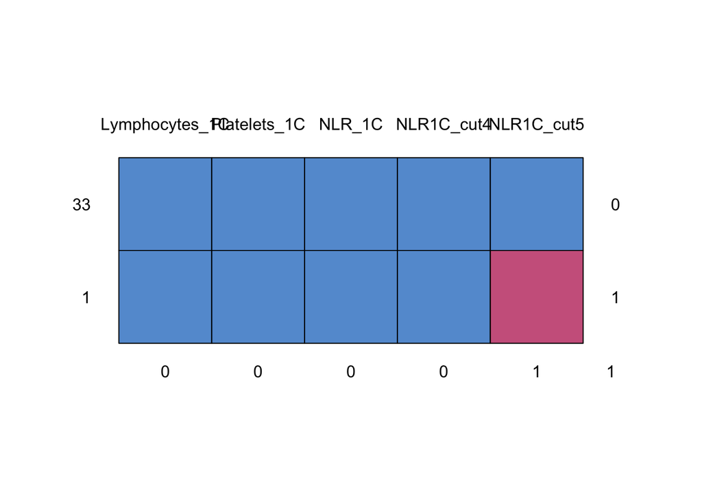

```
##    Lymphocytes_1C Platelets_1C NLR_1C NLR1C_cut4 NLR1C_cut5
## 33              1            1      1          1          1 0
## 1               1            1      1          1          0 1
##                 0            0      0          0          1 1
##
## 🔹 Mostrando patrón de faltantes para variables 46 a 50
```

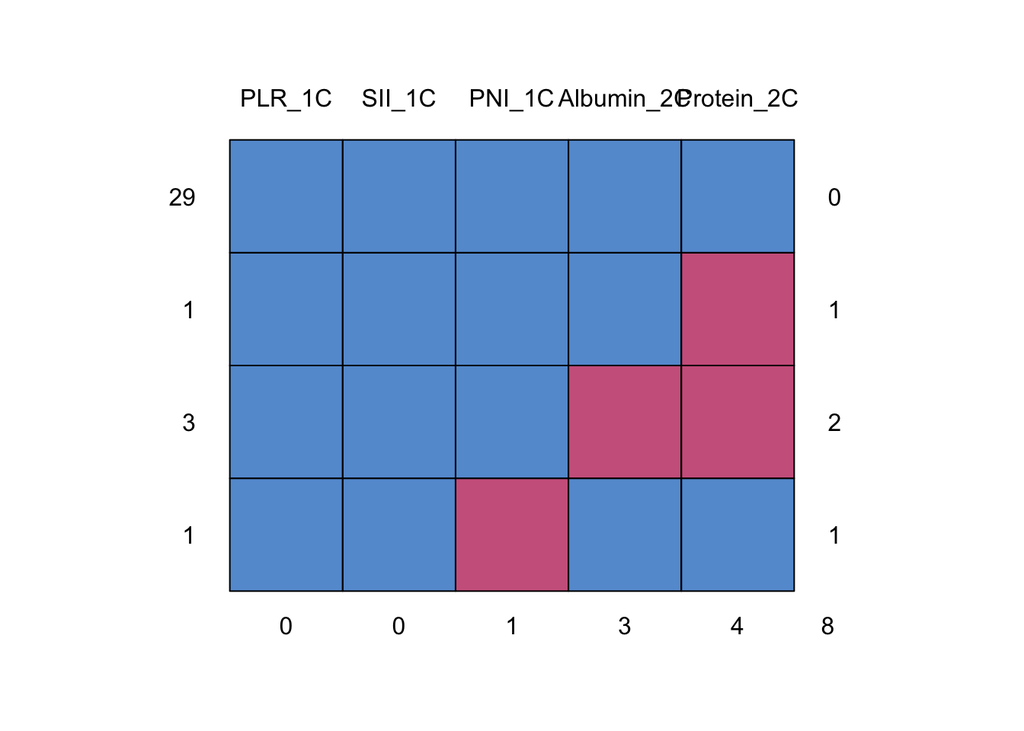

```
##    PLR_1C SII_1C PNI_1C Albumin_2C Protein_2C
## 29      1      1      1          1          1 0
## 1       1      1      1          1          0 1
## 3       1      1      1          0          0 2
## 1       1      1      0          1          1 1
##         0      0      1          3          4 8
##
## 🔹 Mostrando patrón de faltantes para variables 51 a 55
```

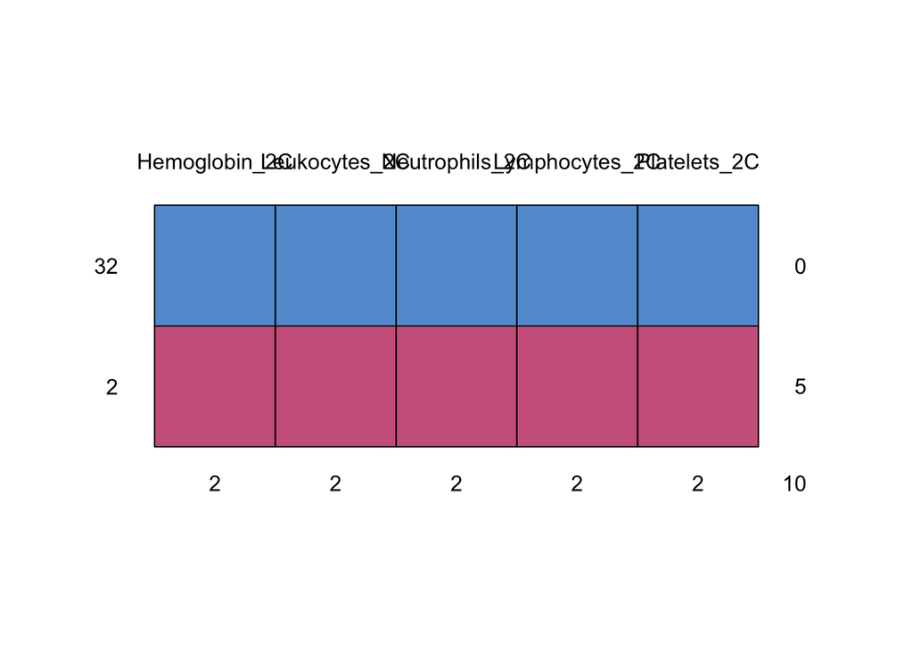

```
##    Hemoglobin_2C Leukocytes_2C Neutrophils_2C Lymphocytes_2C Platelets_2C
## 32             1             1              1              1            1  0
## 2              0             0              0              0            0  5
##                2             2              2              2            2 10
##
## 🔹 Mostrando patrón de faltantes para variables 56 a 60
```

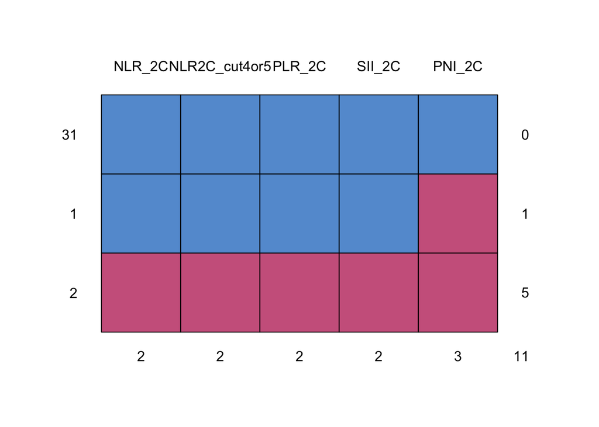

```
##    NLR_2C NLR2C_cut4or5 PLR_2C SII_2C PNI_2C
## 31      1             1      1      1      1  0
## 1       1             1      1      1      0  1
## 2       0             0      0      0      0  5
##         2             2      2      2      3 11
##
## 🔹 Mostrando patrón de faltantes para variables 61 a 65
```

[4 more figures not shown]

```
##    Exitus PFS PFS_censored Education Second_line_treatment
## 27      1   1            1         1                     1 0
## 7       1   1            1         1                     0 1
##         0   0            0         0                     7 7
##
## ⚠️  Bloque 17 tiene solo una columna, se omite.
```

```r
n_vars <- ncol(datos_limpios)

# Dividir en bloques de 5 variables
bloques <- split(1:n_vars, ceiling(seq_along(1:n_vars)/5))

for(i in seq_along(bloques)) {
  sub_data <- datos_limpios[, bloques[[i]], drop = FALSE]

  # Solo si hay al menos 2 columnas
  if (ncol(sub_data) >= 2) {
    cat("\n🔹 Mostrando patrón de faltantes para variables",
        min(bloques[[i]]), "a", max(bloques[[i]]), "\n\n")

    print(md.pattern(sub_data))
  } else {
    cat("\n⚠️  Bloque", i, "tiene solo una columna, se omite.\n")
  }
}
```

En este caso usaremos el metodo de *cart,* este metodo usa árboles de decisión:

- Árboles de regresión para las variables numéricas
- Árboles de clasificación para las variables categoricas (Factor)

Además de que vamos a generar 5 matrices con un máximo de 10 iteraciones por matriz.

```r
imputed_data <- mice(datos_limpios, method = "cart", maxit = 10, m = 5, seed = 123)
```

## 3.2. Selección de mejor matriz de imputación

Este punto es importante, ya que vamos a tratar de seleccionar la matriz de imputación mas acertada, el procedimiento es el siguiente:

- **Para variables Numericas**
  - Localizar las variables numéricas con mayores valores faltantes antes de la imputación
  - Seleccionarlas de las 5 matrices de imputación + la original
  - Crear un grafico de violin donde observaremos de manera local la distribución de los datos
  - Seleccionaremos aquella matriz que siga la distrbución mas parecida a la variable original
- **Para variables Categoricas**
  - Localizar las variables Categóricas con mayores valores faltantes antes de la imputación
  - Seleccionarlas de las 5 matrices de imputación + la original
  - Crear un grafico de barras donde observaremos de manera local la distribución de los datos
  - Seleccionaremos aquella matriz que siga la distrbución mas parecida a la variable original

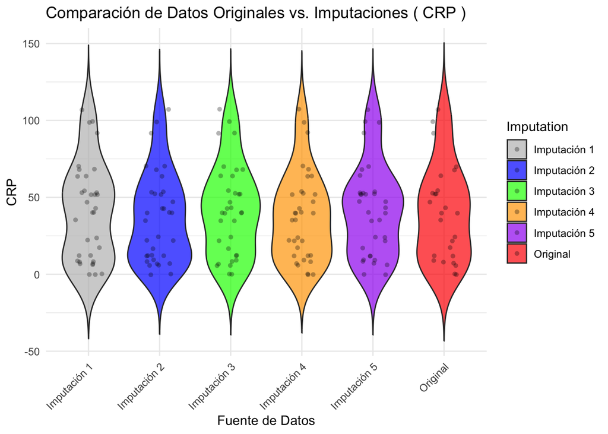

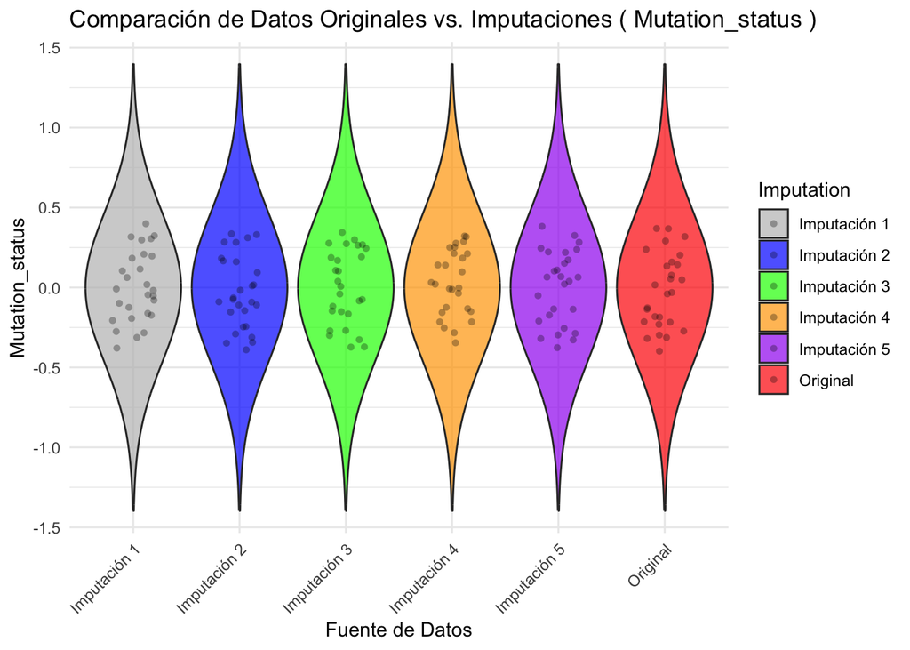

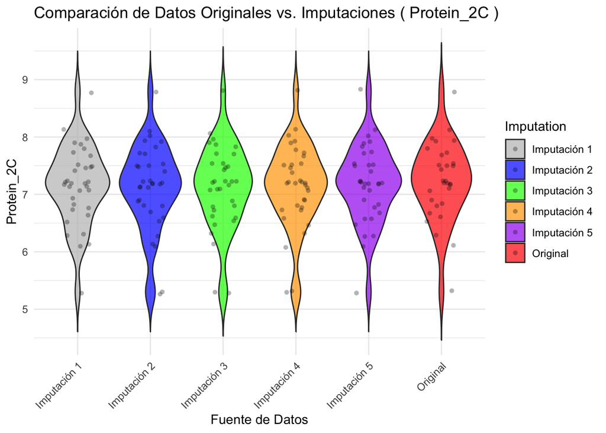

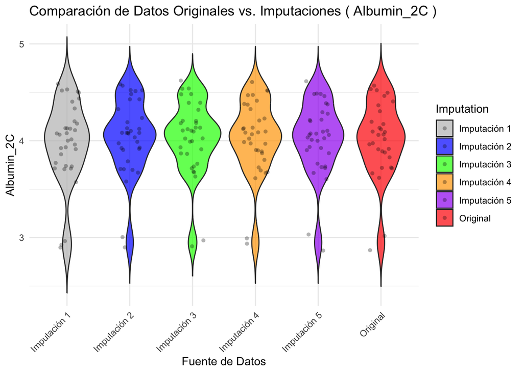

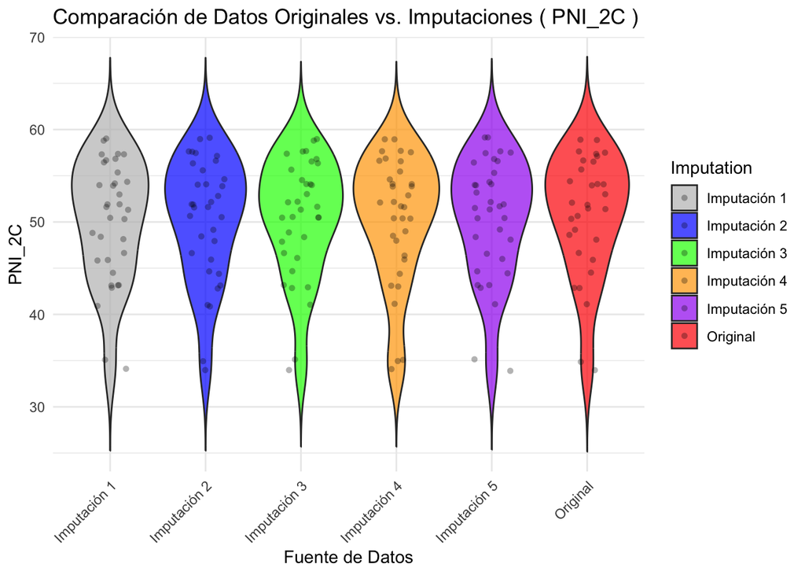

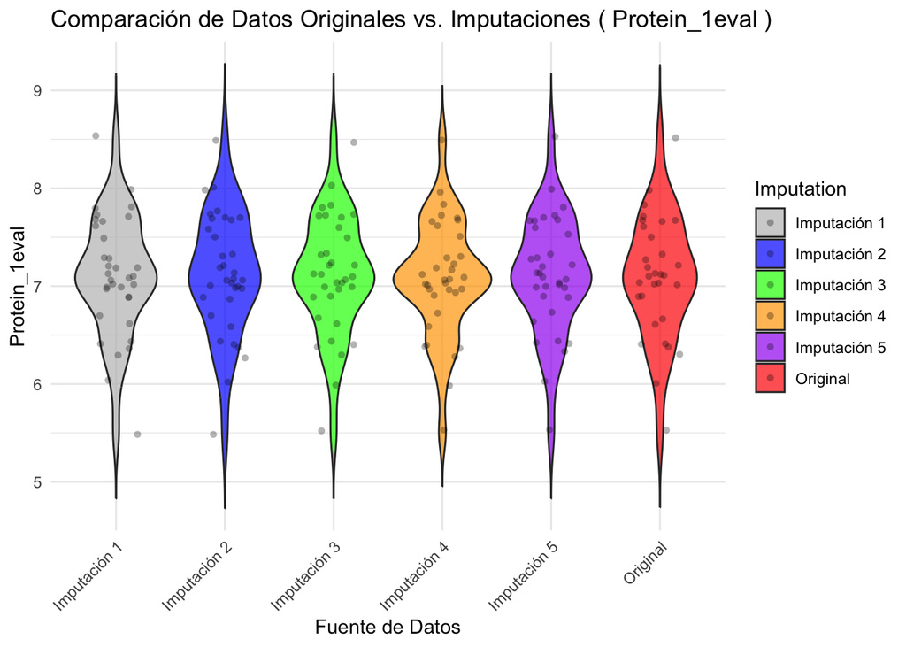

```r
# Variables seleccionadas para graficar
variables_seleccionadas <- c("CRP", "Mutation_status", "Protein_2C", "Albumin_2C", "PNI_2C", "Protein_1eval")

# Extraer las 5 imputaciones generadas por mice y añadir etiquetas
imputed_sets_df <- lapply(1:5, function(i) {
  df <- complete(imputed_data, i)
  df$Imputation <- paste("Imputación", i)  # Etiqueta de imputación
  return(df)
})

# Convertir en un solo dataframe
imputed_full <- do.call(rbind, imputed_sets_df)

# Agregar los datos originales con etiqueta "Original"
datos_limpios$Imputation <- "Original"
imputed_full <- rbind(datos_limpios, imputed_full)

# Generar gráficos uno por uno
for (var in variables_seleccionadas) {

  # Asegurar que la variable sea numérica y eliminar NAs
  imputed_full[[var]] <- as.numeric(imputed_full[[var]])
  imputed_filtered <- imputed_full[!is.na(imputed_full[[var]]), ]

  # Crear y mostrar el violin plot
  p <- ggplot(imputed_filtered, aes(x = Imputation, y = !!sym(var), fill = Imputation)) +
    geom_violin(alpha = 0.7, trim = FALSE) +  # Violin plot sin recorte
    geom_jitter(shape = 16, position = position_jitter(0.2), alpha = 0.3, color = "black") +  # Puntos dispersos
    scale_fill_manual(values = c("gray", "blue", "green", "orange", "purple", "red")) +
    labs(title = paste("Comparación de Datos Originales vs. Imputaciones (", var, ")"),
         x = "Fuente de Datos", y = var) +
    theme_minimal() +
    theme(axis.text.x = element_text(angle = 45, hjust = 1))  # Rotar etiquetas

  print(p)  # Mostrar el gráfico en una nueva página
}
```

Ahora vamos a por las categoricas